# Stat418HW4

Ruifu Jiang

# Abstract

The main puropose of this homework is analyzing the dataset about salary with several machine learning methods. Applying what we learned in calss on sovling real issues is always a good way of better understanding knowledge.

# Executive Summary

The dataset is from https://archive.ics.uci.edu/ml/datasets/Adult. There are totally 32561 observations in this dataset. Each observation includes the age, workclass, fnlwgt, education, education-num, marital-status, occupation, relationship, race, sex, capital-gain, capital-loss, hours-per-week, native-country, and annual salary. 7841 records show annual salary greater than 50K and 24720 records show not greater than 50K.  
The main purpose is to demonstrate the influence of each predictor variable on annual salary whether greater than 50K or not by using machine learning. The methods includes logistic regression, random forest, gradient boosted machine with random search, neural network, and ensembing models. Among all of these methods, AUC is used as a metric for model goodness.

# Dataset

The response variable is the annual salary, individuals earn greater than 50K are marked as “1”, the others are marked as “0”.

In terms of predictor varibales, fnlwgt is the number fo people the census takere believe that obsevation represents, the education_num is the highest level of education in numerical form. These two variables is meaningless and make the model more complicated. Hence they are elimated from the dataset. Below is the summary of the rest dataset.

```
##       age                    workclass             education
##  Min.   :17.00    Private         :22696    HS-grad     :10501
##  1st Qu.:28.00    Self-emp-not-inc: 2541    Some-college: 7291
##  Median :37.00    Local-gov       : 2093    Bachelors   : 5355
##  Mean   :38.58    ?               : 1836    Masters     : 1723
##  3rd Qu.:48.00    State-gov       : 1298    Assoc-voc   : 1382
##  Max.   :90.00    Self-emp-inc    : 1116    11th        : 1175
##                  (Other)          :  981   (Other)      : 5134
##                 marital.status             occupation
##   Divorced             : 4443    Prof-specialty :4140
##   Married-AF-spouse    :   23    Craft-repair   :4099
##   Married-civ-spouse   :14976    Exec-managerial:4066
##   Married-spouse-absent:  418    Adm-clerical   :3770
##   Never-married        :10683    Sales          :3650
##   Separated            : 1025    Other-service  :3295
##   Widowed              :  993   (Other)         :9541
##           relationship                    race            sex
##   Husband       :13193    Amer-Indian-Eskimo:  311    Female:10771
##   Not-in-family : 8305    Asian-Pac-Islander: 1039    Male  :21790
##   Other-relative:  981    Black             : 3124
##   Own-child     : 5068    Other             :  271
##   Unmarried     : 3446    White             :27816
##   Wife          : 1568
##
##   capital.gain    capital.loss    hours.per.week         native.country
##  Min.   :    0   Min.   :   0.0   Min.   : 1.00    United-States:29170
##  1st Qu.:    0   1st Qu.:   0.0   1st Qu.:40.00    Mexico       :  643
##  Median :    0   Median :   0.0   Median :40.00    ?            :  583
##  Mean   : 1078   Mean   :  87.3   Mean   :40.44    Philippines  :  198
##  3rd Qu.:    0   3rd Qu.:   0.0   3rd Qu.:45.00    Germany      :  137
##  Max.   :99999   Max.   :4356.0   Max.   :99.00    Canada       :  121
##                                                   (Other)       : 1709
##        Y
##  Min.   :0.0000
##  1st Qu.:0.0000
##  Median :0.0000
##  Mean   :0.2408
##  3rd Qu.:0.0000
##  Max.   :1.0000
##
```

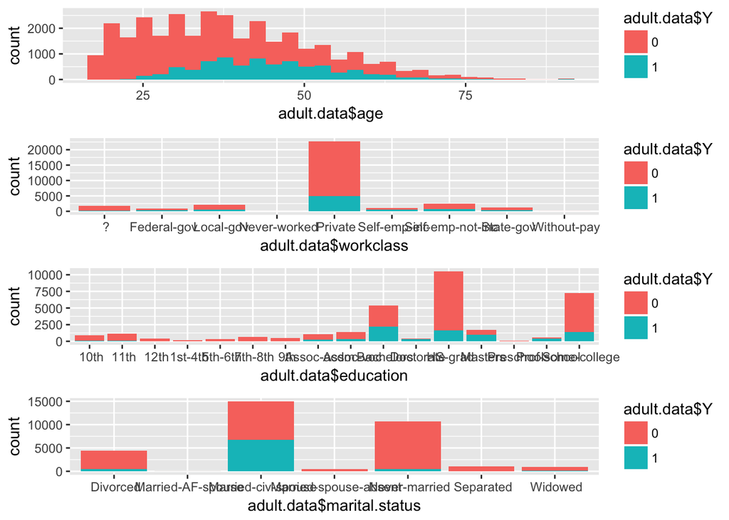

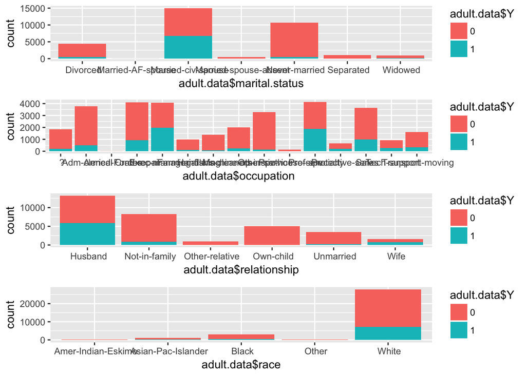

# Data Split

The dataset was randmly selected into three groups, 60% as train set, 20% as validation set, and 20% as test set.

# Statistical Analysis

## 1 Logistic Regression

```
##
## Call:  glmnet(x = X_train, y = adult_train$Y, family = "binomial", lambda = 0.0002853608)
##
##      Df   %Dev    Lambda
## [1,] 90 0.4321 0.0002854
```

```
## [1] 0.9034696
```

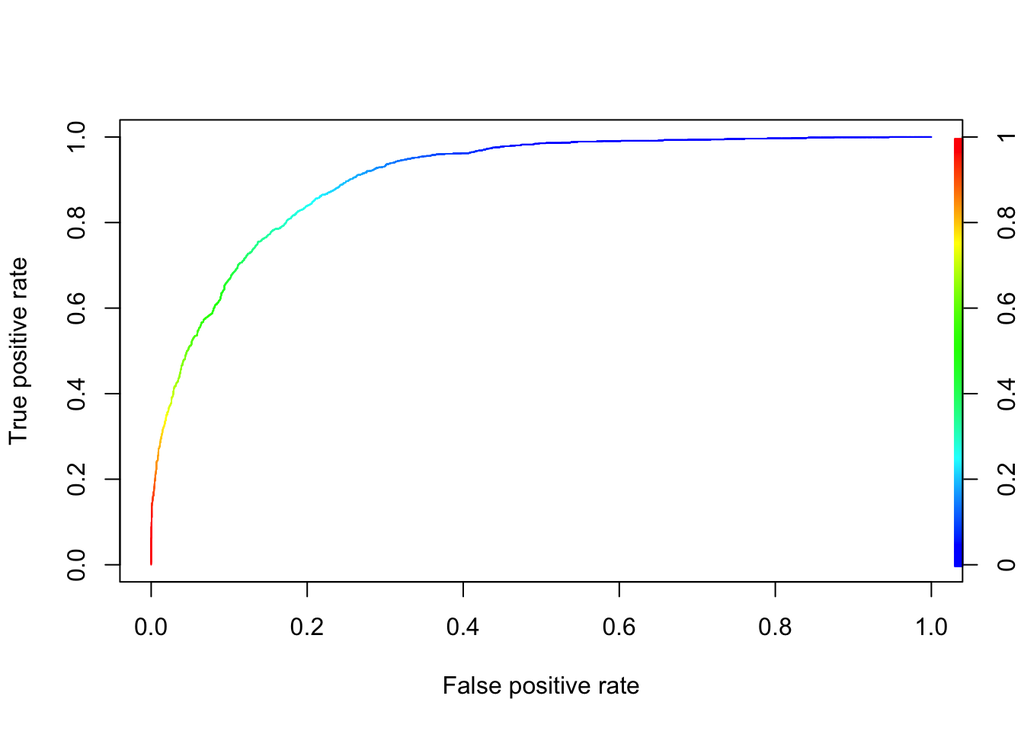

First is to try the logestic regression with the best lambda 0.0002853608.

The AUC is 0.9034696 and it’s close to 1 which means this model is a good fit.  
As we can see from the plot, when the true positive rate increases, the false positive rate increases as well. The AUC is the area under the curve. As long as the area close to 1, it becomes easier to find a point where the true positive rate is high and the false positive rate is low.

## 2 Random Forest

```
## Model Details:
## ==============
##
## H2OBinomialModel: drf
## Model ID:  DRF_model_R_1496816878940_1
## Model Summary:
##   number_of_trees number_of_internal_trees model_size_in_bytes min_depth
## 1             500                      500             9572392        20
##   max_depth mean_depth min_leaves max_leaves mean_leaves
## 1        20   20.00000       1078       1691  1366.69200
##
##
## H2OBinomialMetrics: drf
## ** Reported on training data. **
## ** Metrics reported on Out-Of-Bag training samples **
##
## MSE:  0.09371675
## RMSE:  0.3061319
## LogLoss:  0.3028354
## Mean Per-Class Error:  0.1836257
## AUC:  0.9181551
## Gini:  0.8363103
##
## Confusion Matrix (vertical: actual; across: predicted) for F1-optimal threshold:
##            0    1    Error         Rate
## 0      13508 1370 0.092082  =1370/14878
## 1       1301 3427 0.275169   =1301/4728
## Totals 14809 4797 0.136234  =2671/19606
##
## Maximum Metrics: Maximum metrics at their respective thresholds
##                         metric threshold    value idx
## 1                       max f1  0.413147 0.719580 196
## 2                       max f2  0.188259 0.792556 289
## 3                 max f0point5  0.651659 0.752522 115
## 4                 max accuracy  0.491216 0.866520 166
## 5                max precision  0.999685 1.000000   0
## 6                   max recall  0.000013 1.000000 399
## 7              max specificity  0.999685 1.000000   0
## 8             max absolute_mcc  0.419502 0.630134 194
## 9   max min_per_class_accuracy  0.290644 0.831430 247
## 10 max mean_per_class_accuracy  0.284943 0.832719 249
##
## Gains/Lift Table: Extract with `h2o.gainsLift(<model>, <data>)` or `h2o.gainsLift(<model>, valid=<T/F>, xval=<T/F>)`
```

```
## [1] 0.9167958
```

## 3. Gradient Boosted Machine

The third method is Generalized Boosted Regression Modeling. The AUC is 0.9123521.

[output not shown]

```
## Model Details:
## ==============
##
## H2OBinomialModel: gbm
## Model ID:  GBM_model_R_1496816878940_36
## Model Summary:
##   number_of_trees number_of_internal_trees model_size_in_bytes min_depth
## 1             300                      300             1205132         0
##   max_depth mean_depth min_leaves max_leaves mean_leaves
## 1        20    6.19000          1       1041   215.41000
##
##
## H2OBinomialMetrics: gbm
## ** Reported on training data. **
##
## MSE:  0.02022633
## RMSE:  0.1422193
## LogLoss:  0.07967796
## Mean Per-Class Error:  0.03153474
## AUC:  0.9977592
## Gini:  0.9955185
##
## Confusion Matrix (vertical: actual; across: predicted) for F1-optimal threshold:
##            0    1    Error        Rate
## 0      14676  202 0.013577  =202/14878
## 1        234 4494 0.049492   =234/4728
## Totals 14910 4696 0.022238  =436/19606
##
## Maximum Metrics: Maximum metrics at their respective thresholds
##                         metric threshold    value idx
## 1                       max f1  0.478505 0.953735 191
## 2                       max f2  0.305607 0.964237 238
## 3                 max f0point5  0.615929 0.970416 154
## 4                 max accuracy  0.478505 0.977762 191
## 5                max precision  0.999143 1.000000   0
## 6                   max recall  0.106902 1.000000 309
## 7              max specificity  0.999143 1.000000   0
## 8             max absolute_mcc  0.478505 0.939108 191
## 9   max min_per_class_accuracy  0.373339 0.972293 219
## 10 max mean_per_class_accuracy  0.329848 0.973180 231
##
## Gains/Lift Table: Extract with `h2o.gainsLift(<model>, <data>)` or `h2o.gainsLift(<model>, valid=<T/F>, xval=<T/F>)`
```

```
## [1] 0.9123521
```

```
## Model Details:
## ==============
##
## H2OBinomialModel: gbm
## Model ID:  grd_model_85
## Model Summary:
##   number_of_trees number_of_internal_trees model_size_in_bytes min_depth
## 1            2058                     2058            15667060        12
##   max_depth mean_depth min_leaves max_leaves mean_leaves
## 1        12   12.00000        329        980   495.88046
##
##
## H2OBinomialMetrics: gbm
## ** Reported on training data. **
##
## MSE:  0.04154345
## RMSE:  0.2038221
## LogLoss:  0.1444344
## Mean Per-Class Error:  0.07235632
## AUC:  0.9877378
## Gini:  0.9754755
##
## Confusion Matrix (vertical: actual; across: predicted) for F1-optimal threshold:
##            0    1    Error         Rate
## 0      14355  523 0.035153   =523/14878
## 1        518 4210 0.109560    =518/4728
## Totals 14873 4733 0.053096  =1041/19606
##
## Maximum Metrics: Maximum metrics at their respective thresholds
##                         metric threshold    value idx
## 1                       max f1  0.444711 0.889969 192
## 2                       max f2  0.280477 0.924084 247
## 3                 max f0point5  0.589125 0.913725 146
## 4                 max accuracy  0.468648 0.947006 184
## 5                max precision  0.996347 1.000000   0
## 6                   max recall  0.022436 1.000000 367
## 7              max specificity  0.996347 1.000000   0
## 8             max absolute_mcc  0.444711 0.854979 192
## 9   max min_per_class_accuracy  0.351479 0.939509 223
## 10 max mean_per_class_accuracy  0.333422 0.941676 229
```

[output cut: 17 more lines]

```
##
## Maximum Metrics: Maximum metrics at their respective thresholds
##                         metric threshold    value idx
## 1                       max f1  0.304628 0.700682 233
## 2                       max f2  0.066089 0.793721 337
## 3                 max f0point5  0.644311 0.730266 114
## 4                 max accuracy  0.523754 0.863671 156
## 5                max precision  0.996483 1.000000   0
## 6                   max recall  0.001841 1.000000 398
## 7              max specificity  0.996483 1.000000   0
## 8             max absolute_mcc  0.333033 0.603263 222
## 9   max min_per_class_accuracy  0.206583 0.823023 272
## 10 max mean_per_class_accuracy  0.193523 0.825812 277
##
## Gains/Lift Table: Extract with `h2o.gainsLift(<model>, <data>)` or `h2o.gainsLift(<model>, valid=<T/F>, xval=<T/F>)`
```

```
## [1] 0.9198611
```

## 4. Neural Network

The last method is using neural network for deep learning. There are totally 21 test models including various architectures and tricks with early stopping. Select the best one who has the largest AUC.

```
## Model Details:
## ==============
##
## H2OBinomialModel: deeplearning
## Model ID:  DeepLearning_model_R_1496816878940_5255
## Status of Neuron Layers: predicting Y, 2-class classification, bernoulli distribution, CrossEntropy loss, 63,602 weights/biases, 504.9 KB, 666,604 training samples, mini-batch size 1
##   layer units      type dropout       l1       l2 mean_rate rate_rms
## 1     1   114     Input  0.00 %
## 2     2   200 Rectifier  0.00 % 0.000000 0.000000  0.000148 0.000000
## 3     3   200 Rectifier  0.00 % 0.000000 0.000000  0.000148 0.000000
## 4     4     2   Softmax         0.000000 0.000000  0.000148 0.000000
##   momentum mean_weight weight_rms mean_bias bias_rms
## 1
## 2 0.990000   -0.004702   0.086673  0.432102 0.039947
## 3 0.990000   -0.013722   0.071151  0.944756 0.014691
## 4 0.990000    0.002791   0.327568 -0.000071 0.045740
##
##
## H2OBinomialMetrics: deeplearning
## ** Reported on training data. **
## ** Metrics reported on temporary training frame with 10039 samples **
##
## MSE:  0.08896993
## RMSE:  0.2982783
## LogLoss:  0.2795191
## Mean Per-Class Error:  0.1561982
## AUC:  0.9306511
## Gini:  0.8613023
##
## Confusion Matrix (vertical: actual; across: predicted) for F1-optimal threshold:
##           0    1    Error         Rate
## 0      6647  990 0.129632    =990/7637
## 1       439 1963 0.182764    =439/2402
## Totals 7086 2953 0.142345  =1429/10039
##
## Maximum Metrics: Maximum metrics at their respective thresholds
##                         metric threshold    value idx
## 1                       max f1  0.377529 0.733147 221
## 2                       max f2  0.167067 0.817249 301
## 3                 max f0point5  0.642308 0.758395 122
```

[output cut: 25 more lines]

```
##
## Maximum Metrics: Maximum metrics at their respective thresholds
##                         metric threshold    value idx
## 1                       max f1  0.394361 0.690604 208
## 2                       max f2  0.158365 0.788169 297
## 3                 max f0point5  0.631152 0.713917 124
## 4                 max accuracy  0.620304 0.856310 128
## 5                max precision  0.999849 1.000000   0
## 6                   max recall  0.000366 1.000000 398
## 7              max specificity  0.999849 1.000000   0
## 8             max absolute_mcc  0.402757 0.589255 204
## 9   max min_per_class_accuracy  0.298309 0.822823 241
## 10 max mean_per_class_accuracy  0.271704 0.828234 250
##
## Gains/Lift Table: Extract with `h2o.gainsLift(<model>, <data>)` or `h2o.gainsLift(<model>, valid=<T/F>, xval=<T/F>)`
```

## Ensembling Model

The last step is ensembling 4 models from each method. And the coefficient of best ensembling model is showed below.

```
## Coefficients: glm coefficients
##                                     names coefficients
## 1                               Intercept    -3.253288
## 2          GLM_model_R_1496816878940_5307     1.665269
## 3          DRF_model_R_1496816878940_5325     1.661377
## 4          GBM_model_R_1496816878940_5584     2.712165
## 5 DeepLearning_model_R_1496816878940_5799     0.583126
##   standardized_coefficients
## 1                 -1.691210
## 2                  0.481293
## 3                  0.499825
## 4                  0.884090
## 5                  0.170332
```

# Conclusion

The eaist method is logistic regression, it ran fast and the test AUC is close to 1.  
The random forest ran much slower than logistic regression, but it provided a higher AUC.  
The GBM provided the highest AUC, but the con of GBM is that it’s easily to be overfitted. It’s better to add an early stopping to avoid the overfit. And the hyperparameter choosen with random search cost a very long time.  
Neural netwoking also provided a good performance, but it’s very complicated to set so many hyperparameters and it maybe show more advatages if the dataset is pretty big.  
Comparing those four methods, ensembling those them is a very good choice for this analysis. It gave each model a weight and combine them all to build a better model.